# meta_analysis_with_R

董彪

2023-01-16

```r
# pkgs <- c("mada", "meta", "metafor", "metasens", "mvmeta", "netmeta",
#           "rmeta", "ellipse")
# install.packages(pkgs, repos="http://cran.at.r-project.org/")
```

# Standard Methods

## 1 Fixed Effect and Random Effects Meta-Analysis

### 1.1 Effect Measures for Continus Outcomes

Variable names in R datasets for meta-analysis of continuous responses

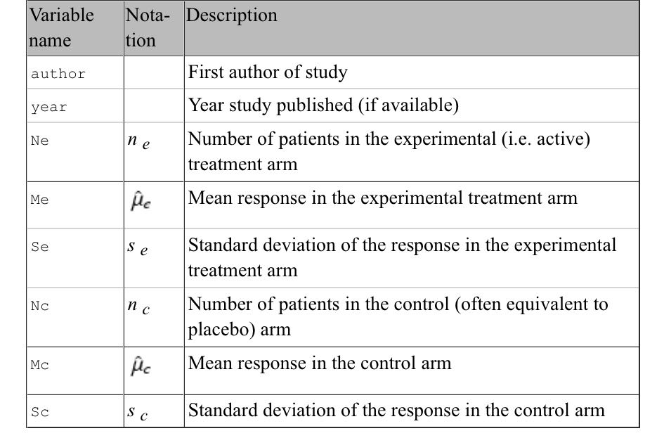

variable name

#### **1.1.1 Mean Difference**

THe estimated mean difference $\hat \mu_k = \hat \mu_{ek} - \hat \mu_{ck}$  
variance estimate : $Var(\hat \mu_k) = \frac {s_{ek}^2}{n_{ek}} + \frac {s_{ck}^2}{n_ck}$ An approximate two-sided (1 - $\alpha$) confidence interval for the mean difference  
is given by $(\hat \mu_{ek} - \hat \mu_{ck}) = Z_{1 - \frac {\alpha}{2}} \sqrt {\frac {s_{ek}^2}{n_{ek}} + \frac {s_{ck}^2}{n_ck}}$

```r
# 1. Read in the data
library(meta)
data1 <- read.csv("data/dataset01.csv", as.is=TRUE)
# 2. Calculate mean difference and its standard error for
#    study 1 (Boner 1988) of dataset data1:
MD <- with(data1[1,], Me - Mc)
seMD <- with(data1[1,], sqrt(Se^2/Ne + Sc^2/Nc))
# 3. Print mean difference and limits of 95% confidence
#    interval using round function to show only two digits:
# base R
round(c(MD, MD + c(-1,1) * qnorm(1-(0.05/2)) * seMD), 2)
```

```
## [1]  -7.23 -21.11   6.65
```

```r
with(data1[1, ],
     print(metacont(Ne, Me, Se, Nc, Mc, Sc),
           digits=2))
```

```
## Number of observations: o = 26
##
##     MD         95%-CI     z p-value
##  -7.23 [-21.11; 6.65] -1.02  0.3074
##
## Details:
## - Inverse variance method
```

```r
# print(metacont(Ne, Me, Se, Nc, Mc, Sc,
#                data=data1, subset=1), digits=2)
zscore <- MD/seMD
round(c(zscore, 2*pnorm(abs(zscore), lower.tail=FALSE)), 4)
```

```
## [1] -1.0206  0.3074
```

#### **1.1.2 Standardised Mean Difference**

In many settings differences in the individual studies SDM : $\hat g_K = (1 - \frac {3}{4n_k - 9}) \frac {\hat \mu_{ek} - \hat \mu_{ck}}{\sqrt ((n_{ek} - 1)s_{ek}^2 + (n_{ck} -1)s_{ck}^2)/(n_{k} - 2)}$  
variance : $Var(\hat g_k) = \frac {n_k}{n_{ek}\times{n_{ck}}} + \frac {\hat g_k^2}{2(n_k - 3.94)}$  
confidence interval : $\hat g_k \pm Z_{1 - \frac {\alpha}{2}} \sqrt Var(\hat g_k)$

```r
# 1. Read in the data:
data2 <- read.csv("data/dataset02.csv")
# 2. As usual, to view an object, type its name:
data2
```

| author | Ne | Me | Se | Nc | Mc | Sc |
| --- | --- | --- | --- | --- | --- | --- |
| Blashki(75%150) | 13 | 6.40 | 5.40 | 18 | 11.40 | 9.60 |
| Hormazabal(86) | 17 | 11.00 | 8.20 | 16 | 19.00 | 8.20 |
| Jacobson(75-100) | 10 | 17.50 | 8.80 | 6 | 23.00 | 8.80 |
| Jenkins(75) | 7 | 12.30 | 9.90 | 7 | 20.00 | 10.50 |
| Lecrubier(100) | 73 | 15.70 | 10.60 | 73 | 18.70 | 10.60 |
| Murphy(100) | 26 | 8.50 | 11.00 | 28 | 14.50 | 11.00 |
| Nandi(97) | 17 | 25.50 | 24.00 | 10 | 53.20 | 11.20 |
| Petracca(100) | 11 | 6.20 | 7.60 | 10 | 10.00 | 7.60 |
| Philipp(100) | 105 | -8.10 | 3.90 | 46 | -8.50 | 5.20 |
| Rampello(100) | 22 | 13.40 | 2.30 | 19 | 19.70 | 1.30 |

[output cut: 7 more lines]

```r
# 3. Calculate total sample sizes
summary(data2$Ne+data2$Nc)
```

```
##    Min. 1st Qu.  Median    Mean 3rd Qu.    Max.
##   14.00   26.00   31.00   53.06   54.00  151.00
```

```r
# 1. Calculate standardised mean difference (SMD) and
#    its standard error (seSMD) for study 1 (Blashki) of
#    dataset data2:
N <- with(data2[1,], Ne + Nc)
SMD <- with(data2[1,],
            (1 - 3/(4 * N - 9)) * (Me - Mc) /
            sqrt(((Ne - 1) * Se^2 + (Nc - 1) * Sc^2)/(N - 2)))
seSMD <- with(data2[1,],
              sqrt(N/(Ne * Nc) + SMD^2/(2 * (N - 3.94))))
# 2. Print standardised mean difference and limits of 95% CI
#    interval using round function to show only two digits:
round(c(SMD, SMD + c(-1,1) * qnorm(1-(0.05/2)) * seSMD), 2)
```

```
## [1] -0.60 -1.33  0.13
```

```r
print(metacont(Ne, Me, Se, Nc, Mc, Sc, sm="SMD",
               data=data2, subset=1), digits=2)
```

```
## Number of observations: o = 31
##
##     SMD        95%-CI     z p-value
## 1 -0.60 [-1.33; 0.13] -1.61  0.1082
##
## Details:
## - Inverse variance method
## - Hedges' g (bias corrected standardised mean difference; using exact formulae)
```

### **1.2 Fixed Effect Model**

The fixed effect model is  
$\hat \theta_k = \theta + \sigma_k \epsilon_k$, $\epsilon_k \sim N(0,1)$  
Fix effect estimate :  
$\hat \theta_k = \frac {\displaystyle \sum^{K}_{k=1} \hat \theta_k / \sigma_k^2}{\displaystyle \sum^{K}_{k=1} 1 / \sigma_k^2} = \frac {\displaystyle \sum^{K}_{k=1} \hat \theta_k w_k}{\displaystyle \sum^{K}_{k=1} w_k}$  
The variance of $\hat \theta_F$ is estimated by:  
$Var(\hat \theta_F) = \frac {1}{\sum^{K}_{k=1} w_k}$  
$(1 - \alpha)$ confidence interval for $\hat \theta_F$: $\hat \theta_F \pm Z_{1 - \frac {\alpha}{2}} S.E.(\hat \theta_F)$

The fixed effect estimate $\hat \theta_F$ and its variance can be calculated  
using the following quantities:  
$\hat \theta_k = \hat \mu_k$  
$\sigma_k^2 = Var(\hat \mu_k)$

```r
# 1. Calculate mean difference, variance and weights
MD <- with(data1, Me - Mc)
varMD <- with(data1, Se^2/Ne + Sc^2/Nc)
weight <- 1/varMD
# 2. Calculate the inverse variance estimator
round(weighted.mean(MD, weight), 4)
```

```
## [1] -15.514
```

```r
# 3. Calculate the variance
round(1/sum(weight), 4)
```

```
## [1] 1.4126
```

```r
# Calculate with metaR
mc1 <- metacont(Ne, Me, Se, Nc, Mc, Sc,
                data=data1,
                studlab=paste(author, year))
round(c(mc1$TE.fixed, mc1$seTE.fixed^2), 4)
```

```
## [1] -15.5140   1.4126
```

```r
print(mc1, digits=1)
```

```
## Number of studies combined: k = 17
## Number of observations: o = 480
##
##                         MD         95%-CI      z  p-value
## Common effect model  -15.5 [-17.8; -13.2] -13.05 < 0.0001
## Random effects model -15.6 [-18.1; -13.1] -12.28 < 0.0001
##
## Quantifying heterogeneity:
##  tau^2 = 2.5162 [0.0000; 42.5899]; tau = 1.5862 [0.0000; 6.5261]
##  I^2 = 8.9% [0.0%; 45.3%]; H = 1.05 [1.00; 1.35]
##
## Test of heterogeneity:
##      Q d.f. p-value
##  17.57   16  0.3496
##
## Details on meta-analytical method:
## - Inverse variance method
## - Restricted maximum-likelihood estimator for tau^2
## - Q-Profile method for confidence interval of tau^2 and tau
```

```r
# The weight of study
mc1$w.fixed[1]
```

```
## [1] 0.01992783
```

```r
sum(mc1$w.fixed)
```

```
## [1] 0.7079028
```

```r
round(100*mc1$w.fixed[1] / sum(mc1$w.fixed), 2)
```

```
## [1] 2.82
```

[figure not shown]

```r
forest(mc1, comb.random=FALSE, xlab=
       "Difference in mean response (intervention - control)
units: maximum % fall in FEV1",
       xlim=c(-50,10), xlab.pos=-20, smlab.pos=-20)
```

```r
# 1. Apply generic inverse variance method
mc1.gen <- metagen(mc1$TE, mc1$seTE, sm="MD")
# 2. Same result
mc1.gen <- metagen(TE, seTE, data=mc1, sm="MD")
# 3. Print results for fixed effect and random effects method
c(mc1$TE.fixed, mc1$TE.random)
```

```
## [1] -15.51403 -15.64702
```

```r
c(mc1.gen$TE.fixed, mc1.gen$TE.random)
```

```
## [1] -15.51403 -15.64702
```

```r
# 1. Calculate standardised mean difference,
#    variance and weights
N <- with(data2, Ne + Nc)
SMD <- with(data2,
            (1 - 3/(4 * N - 9)) * (Me - Mc)/
            sqrt(((Ne - 1) * Se^2 + (Nc - 1) * Sc^2)/(N - 2)))
varSMD <- with(data2,
               N/(Ne * Nc) + SMD^2/(2 * (N - 3.94)))
weight <- 1/varSMD
# 2. Calculate the inverse variance estimator
round(weighted.mean(SMD, weight), 4)
```

```
## [1] -0.3915
```

```r
# 3. Calculate the variance
round(1/sum(weight), 4)
```

```
## [1] 0.0049
```

```r
mc2 <- metacont(Ne, Me, Se, Nc, Mc, Sc, sm="SMD",
                data=data2)
round(c(mc2$TE.fixed, mc2$seTE.fixed^2), 4)
```

```
## [1] -0.3918  0.0049
```

```r
print(summary(mc2), digits=2)
```

```
##      SMD         95%-CI %W(common) %W(random)
## 1  -0.60 [-1.33;  0.13]        3.5        5.8
## 2  -0.95 [-1.68; -0.23]        3.6        5.8
## 3  -0.59 [-1.63;  0.45]        1.7        4.5
## 4  -0.71 [-1.80;  0.39]        1.6        4.3
## 5  -0.28 [-0.61;  0.04]       17.6        7.5
## 6  -0.54 [-1.08;  0.01]        6.3        6.6
## 7  -1.32 [-2.19; -0.45]        2.5        5.2
## 8  -0.48 [-1.35;  0.39]        2.5        5.2
## 9   0.09 [-0.25;  0.44]       15.6        7.5
## 10 -3.24 [-4.20; -2.28]        2.0        4.8
## 11  0.00 [-0.74;  0.74]        3.4        5.7
## 12 -0.71 [-1.20; -0.21]        7.6        6.9
## 13 -0.47 [-1.25;  0.31]        3.1        5.6
## 14 -0.18 [-0.51;  0.14]       18.0        7.6
## 15 -0.03 [-0.60;  0.55]        5.6        6.5
## 16 -1.16 [-2.08; -0.25]        2.2        5.0
## 17 -0.21 [-0.97;  0.54]        3.3        5.7
##
## Number of studies combined: k = 17
## Number of observations: o = 902
##
##                        SMD         95%-CI     z  p-value
## Common effect model  -0.39 [-0.53; -0.26] -5.62 < 0.0001
## Random effects model -0.61 [-0.93; -0.28] -3.63   0.0003
##
## Quantifying heterogeneity:
##  tau^2 = 0.3415 [0.1422; 1.1791]; tau = 0.5844 [0.3771; 1.0859]
##  I^2 = 72.6% [55.5%; 83.1%]; H = 1.91 [1.50; 2.43]
##
## Test of heterogeneity:
##      Q d.f.  p-value
##  58.38   16 < 0.0001
##
## Details on meta-analytical method:
## - Inverse variance method
## - Restricted maximum-likelihood estimator for tau^2
## - Q-Profile method for confidence interval of tau^2 and tau
## - Hedges' g (bias corrected standardised mean difference; using exact formulae)
```

### **1.3 Random Effects Model**

more variable than assumed in fixed model  
$\hat \theta_k = \theta +u + \sigma_k \epsilon_k$, $\epsilon_k \sim N(0, 1), u_k \sim N(0, r^2)$